# Ever experienced financial problems

# 1 Description of DataSchema variable

The description of harmonised variables is the following:

- Short name: `fin_prob`
- Variable label: `Ever experienced financial problems?`
- Domain: `Social environment`
- Value type: `categorical`
- Categories:

| **Code** | **Category Label** |
| --- | --- |
| 0 | No |
| 1 | Yes |

- Category missings:

| **Code** | **Category Label** |
| --- | --- |
| 991 | CAPI/interviewer error |
| 992 | Impute |
| 993 | Disable to measure |
| 994 | Not attempt/not done |
| 995 | Does not answer |
| 996 | Not applicable |
| 997 | Refuse |
| 998 | Do not know |
| 999 | Missing |

# 2 Data process

## 2.1 England

### 2.1.1 Wave 1

#### 2.1.1.1 Study-specific variable description

The study-specific variable elected to be harmonised is:

- Name: `iafcon`
- Label: `Which of the phrases on the card best describes how you (and your spouse) are getting along financially these days?`
- Categories:
  - `1 = manage very well`
  - `2 = manage quite well`
  - `3 = get by alright`
  - `4 = don t manage very well`
  - `5 = have some financial difficulties`
  - `6 = have severe financial difficulties`
- Missings:
  - `-9 = Refusal`
  - `-8 = Don't Know`
  - `-1 = Not applicable`
- Description:

IAFCON

| Sample size | Missing values |
| --- | --- |
| 12099 | 952 |

Category

|  | 1 | 2 | 3 | 4 | 5 | 6 |
| --- | --- | --- | --- | --- | --- | --- |
| Frequency | 3447.00 | 3815.00 | 3315.0 | 207.00 | 293.00 | 70.00 |
| Percentage | 28.49 | 31.53 | 27.4 | 1.71 | 2.42 | 0.58 |

Type of missing

|  | -9 | -8 | -1 | NA |
| --- | --- | --- | --- | --- |
| Frequency | 38.00 | 9.00 | 905.00 | 0 |
| Percentage | 0.31 | 0.07 | 7.48 | 0 |

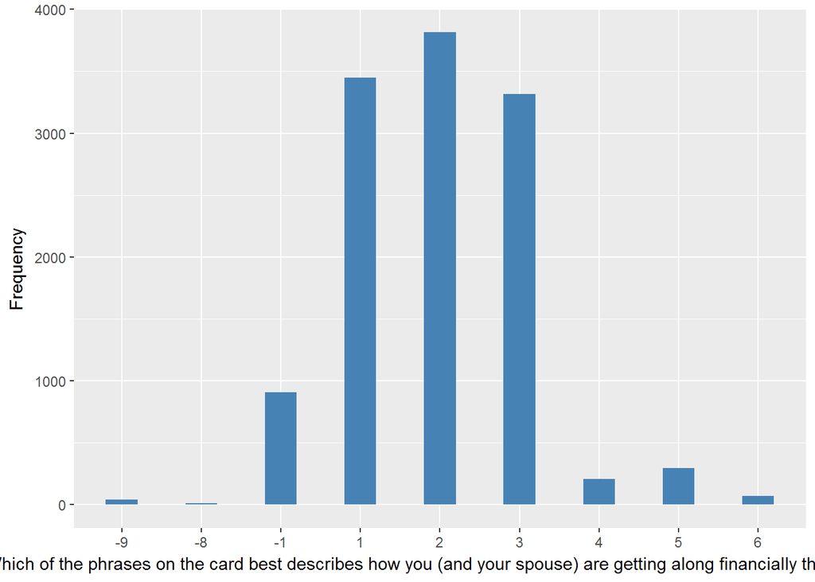

#### 2.1.1.2 Harmonisation algorithm

To compute the harmonize variable from the study-specific variable it has to be recoded as follows:

- `1,2,3 into 0`
- `4,5,6 into 1`
- `-9 into 997`
- `-8 into 998`
- `-1 into 996`
- `NA into 999`

**R script:**

```r
ELSA_ds_w1 <- tibble(id = ELSA_w1_fin_prob$id)
ELSA_ds_w1$fin_prob <- car::recode(as.vector(ELSA_w1_fin_prob$iafcon), "1:3='0'; 4:6='1'; -9='997'; -8='998'; -1='996'; NA='999'")
ELSA_ds_w1$fin_prob <- labelled(ELSA_ds_w1$fin_prob, labels = c(No = 0, Yes = 1,
    Missing = 999, `Do not know` = 998, Refuse = 997, `Not applicable` = 996,
    `Don't answer` = 995, `Not attempt/not done/not yet recorded` = 994, `Disable to measure` = 993,
    Impute = 992, `CAPI/interviewer error` = 991))
```

#### 2.1.1.3 Statistical description of the new harmonised variable

| Sample size | Missing values |
| --- | --- |
| 12099 | 952 |

Category

|  | 0 | 1 |
| --- | --- | --- |
| Frequency | 10577.00 | 570.00 |
| Percentage | 87.42 | 4.71 |

Type of missing

|  | 991 | 992 | 993 | 994 | 995 | 996 | 997 | 998 | 999 | NA |
| --- | --- | --- | --- | --- | --- | --- | --- | --- | --- | --- |
| Frequency | 0 | 0 | 0 | 0 | 0 | 905.00 | 38.00 | 9.00 | 0 | 0 |
| Percentage | 0 | 0 | 0 | 0 | 0 | 7.48 | 0.31 | 0.07 | 0 | 0 |

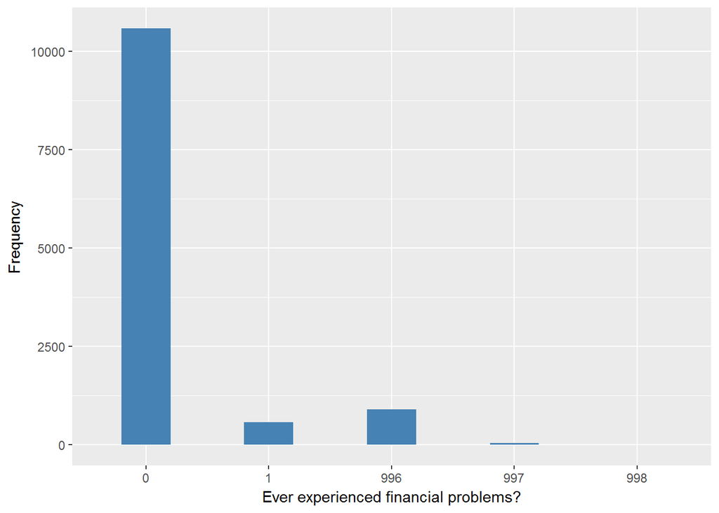

#### 2.1.1.4 Validation

[output not shown]

### 2.1.2 Wave 2

#### 2.1.2.1 Study-specific variable description

The study-specific variable elected to be harmonised is:

- Name: `iafcon`
- Label: `Which of the phrases on the card best describes how you (and your spouse) are getting along financially these days?`
- Categories:
  - `1 = manage very well`
  - `2 = manage quite well`
  - `3 = get by alright`
  - `4 = don t manage very well`
  - `5 = have some financial difficulties`
  - `6 = have severe financial difficulties`
- Missings:
  - `-9 = Refusal`
  - `-8 = Don't Know`
  - `-1 = Not applicable`
- Name: `fin_prob` from the previous wave
- Description:

IAFCON

| Sample size | Missing values |
| --- | --- |
| 9432 | 621 |

Category

|  | 1 | 2 | 3 | 4 | 5 | 6 |
| --- | --- | --- | --- | --- | --- | --- |
| Frequency | 3152.00 | 3044.00 | 2272.00 | 119.00 | 182.00 | 42.00 |
| Percentage | 33.42 | 32.27 | 24.09 | 1.26 | 1.93 | 0.45 |

Type of missing

|  | -9 | -8 | -1 | NA |
| --- | --- | --- | --- | --- |
| Frequency | 11.00 | 6.00 | 604.0 | 0 |
| Percentage | 0.12 | 0.06 | 6.4 | 0 |

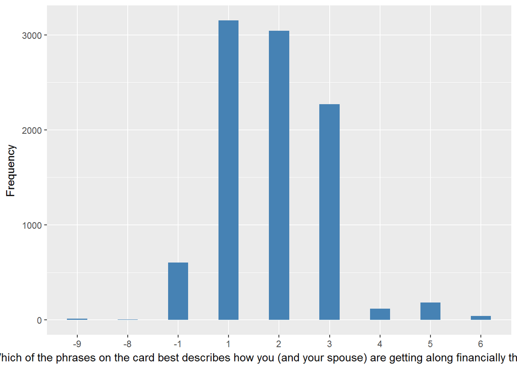

#### 2.1.2.2 Harmonisation algorithm

To compute the harmonize variable from the study-specific variable it has to be recoded as follows:

- `if fin_prob=1 or iafcon in 4,5,6 - into 1`
- `1,2,3 into 0`
- `-9 into 997`
- `-8 into 998`
- `-1 into 996`
- `NA into 999`

**R script:**

```r
same_indiv <- function(old, new) {

    new_2 <- matrix(NA, nrow = dim(new)[1], ncol = dim(old)[2])
    colnames(new_2) <- colnames(old)
    oldm <- as.matrix(old)

    for (i in 1:length(new$id)) {
        if (sum(new$id[i] == old$id) >= 1) {
            new_2[i, ] <- oldm[which(new$id[i] == old$id), ]
        } else {
            new_2[i, ] <- c(new$id[i], rep_len(NA, dim(old)[2] - 1))
        }
    }
    new_2 <- data.frame(new_2)
    new_22 <- data.frame(id = new_2$id, iafcon = new$iafcon, fin_prob = new_2$fin_prob)
    # id = new_2$id colname_form_OLD_table = new_2$colname_form_OLD_table
    # colname_form_NEW_table = new$colname_form_NEW_table
    new_22
}

# old = ELSA_ds_w1 (fin_prob) new = ELSA_w2_fin_prob (iafcon)

ELSA_w2_fin_prob_2 <- same_indiv(ELSA_ds_w1, ELSA_w2_fin_prob)

ELSA_ds_w2 <- tibble(id = ELSA_w2_fin_prob_2$id)

ELSA_w2_fin_prob_2$fin_prob <- car::recode(as.vector(ELSA_w2_fin_prob_2$fin_prob),
    "NA='-999'")
ELSA_w2_fin_prob_2$iafcon <- car::recode(as.vector(ELSA_w2_fin_prob_2$iafcon),
    "NA='-999'")

ELSA_ds_w2$fin_prob <- c(NA)
for (i in 1:dim(ELSA_w2_fin_prob_2[1])) {
    if (ELSA_w2_fin_prob_2$fin_prob[i] == 1 | ELSA_w2_fin_prob_2$iafcon[i] %in%
        c(4, 5, 6)) {
        ELSA_ds_w2$fin_prob[i] = 1
    } else if (ELSA_w2_fin_prob_2$iafcon[i] %in% c(1, 2, 3)) {
        ELSA_ds_w2$fin_prob[i] = 0
    } else if (ELSA_w2_fin_prob_2$iafcon[i] == -9) {
        ELSA_ds_w2$fin_prob[i] = 997
    } else if (ELSA_w2_fin_prob_2$iafcon[i] == -8) {
        ELSA_ds_w2$fin_prob[i] = 998
    } else if (ELSA_w2_fin_prob_2$iafcon[i] == -1) {
        ELSA_ds_w2$fin_prob[i] = 996
    }
}

ELSA_ds_w2$fin_prob <- car::recode(as.vector(ELSA_ds_w2$fin_prob), "NA='999'")
ELSA_ds_w2$fin_prob <- labelled(ELSA_ds_w2$fin_prob, labels = c(No = 0, Yes = 1,
    Missing = 999, `Do not know` = 998, Refuse = 997, `Not applicable` = 996,
    `Don't answer` = 995, `Not attempt/not done/not yet recorded` = 994, `Disable to measure` = 993,
    Impute = 992, `CAPI/interviewer error` = 991))
```

#### 2.1.2.3 Statistical description of the new harmonised variable

| Sample size | Missing values |
| --- | --- |
| 9432 | 601 |

Category

|  | 0 | 1 |
| --- | --- | --- |
| Frequency | 8219.00 | 612.00 |
| Percentage | 87.14 | 6.49 |

Type of missing

|  | 991 | 992 | 993 | 994 | 995 | 996 | 997 | 998 | 999 | NA |
| --- | --- | --- | --- | --- | --- | --- | --- | --- | --- | --- |
| Frequency | 0 | 0 | 0 | 0 | 0 | 585.0 | 10.00 | 6.00 | 0 | 0 |
| Percentage | 0 | 0 | 0 | 0 | 0 | 6.2 | 0.11 | 0.06 | 0 | 0 |

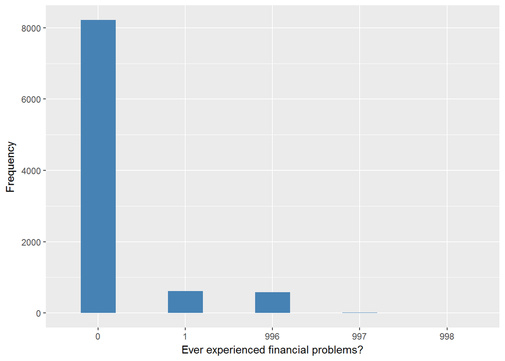

#### 2.1.2.4 Validation

### 2.1.3 Wave 3

#### 2.1.3.1 Study-specific variable description

The study-specific variable elected to be harmonised is:

- Name: `iafcon`
- Label: `Which of the phrases on the card best describes how you (and your spouse) are getting along financially these days?`
- Categories:
  - `1 = manage very well`
  - `2 = manage quite well`
  - `3 = get by alright`
  - `4 = don t manage very well`
  - `5 = have some financial difficulties`
  - `6 = have severe financial difficulties`
- Missings:
  - `-9 = Refusal`
  - `-8 = Don't Know`
  - `-2 = Schedule not applicable`
  - `-1 = Not applicable`
- Name: `fin_prob` from the previous wave
- Description:

IAFCON

| Sample size | Missing values |
| --- | --- |
| 9771 | 687 |

Category

|  | 1 | 2 | 3 | 4 | 5 | 6 |
| --- | --- | --- | --- | --- | --- | --- |
| Frequency | 3204.00 | 3133.00 | 2317.00 | 127.0 | 243.00 | 60.00 |
| Percentage | 32.79 | 32.06 | 23.71 | 1.3 | 2.49 | 0.61 |

Type of missing

|  | -9 | -8 | -2 | -1 | NA |
| --- | --- | --- | --- | --- | --- |
| Frequency | 9.00 | 24.00 | 0 | 654.00 | 0 |
| Percentage | 0.09 | 0.25 | 0 | 6.69 | 0 |

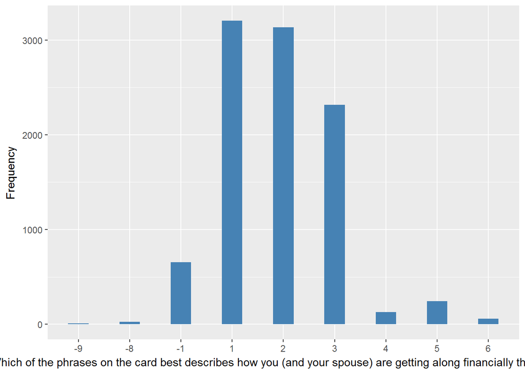

#### 2.1.3.2 Harmonisation algorithm

To recode the harmonize variable from the study-specific variable it has to be recoded as follows:

- `if fin_prob=1 or iafcon in 4,5,6 - into 1`
- `1,2,3 into 0`
- `-9 into 997`
- `-8 into 998`
- `-1 or -2 into 996`
- `NA into 999`

**R script:**

```r
same_indiv <- function(old, new) {

    new_2 <- matrix(NA, nrow = dim(new)[1], ncol = dim(old)[2])
    colnames(new_2) <- colnames(old)
    oldm <- as.matrix(old)

    for (i in 1:length(new$id)) {
        if (sum(new$id[i] == old$id) >= 1) {
            new_2[i, ] <- oldm[which(new$id[i] == old$id), ]
        } else {
            new_2[i, ] <- c(new$id[i], rep_len(NA, dim(old)[2] - 1))
        }
    }
    new_2 <- data.frame(new_2)
    new_22 <- data.frame(id = new_2$id, iafcon = new$iafcon, fin_prob = new_2$fin_prob)
    # id = new_2$id colname_form_OLD_table = new_2$colname_form_OLD_table
    # colname_form_NEW_table = new$colname_form_NEW_table
    new_22
}

# old = ELSA_ds_w2 (fin_prob) new = ELSA_w3_fin_prob (iafcon)

ELSA_w3_fin_prob_2 <- same_indiv(ELSA_ds_w2, ELSA_w3_fin_prob)

ELSA_ds_w3 <- tibble(id = ELSA_w3_fin_prob_2$id)

ELSA_w3_fin_prob_2$fin_prob <- car::recode(as.vector(ELSA_w3_fin_prob_2$fin_prob),
    "NA='-999'")
ELSA_w3_fin_prob_2$iafcon <- car::recode(as.vector(ELSA_w3_fin_prob_2$iafcon),
    "NA='-999'")

ELSA_ds_w3$fin_prob <- c(NA)
for (i in 1:dim(ELSA_w3_fin_prob_2[1])) {
    if (ELSA_w3_fin_prob_2$fin_prob[i] == 1 | ELSA_w3_fin_prob_2$iafcon[i] %in%
        c(4, 5, 6)) {
        ELSA_ds_w3$fin_prob[i] = 1
    } else if (ELSA_w3_fin_prob_2$iafcon[i] %in% c(1, 2, 3)) {
        ELSA_ds_w3$fin_prob[i] = 0
    } else if (ELSA_w3_fin_prob_2$iafcon[i] == -9) {
        ELSA_ds_w3$fin_prob[i] = 997
    } else if (ELSA_w3_fin_prob_2$iafcon[i] == -8) {
        ELSA_ds_w3$fin_prob[i] = 998
    } else if (ELSA_w3_fin_prob_2$iafcon[i] %in% c(-1, -2)) {
        ELSA_ds_w3$fin_prob[i] = 996
    }
}

ELSA_ds_w3$fin_prob <- car::recode(as.vector(ELSA_ds_w3$fin_prob), "NA='999'")
ELSA_ds_w3$fin_prob <- labelled(ELSA_ds_w3$fin_prob, labels = c(No = 0, Yes = 1,
    Missing = 999, `Do not know` = 998, Refuse = 997, `Not applicable` = 996,
    `Don't answer` = 995, `Not attempt/not done/not yet recorded` = 994, `Disable to measure` = 993,
    Impute = 992, `CAPI/interviewer error` = 991))
```

#### 2.1.3.3 Statistical description of the new harmonised variable

| Sample size | Missing values |
| --- | --- |
| 9771 | 658 |

Category

|  | 0 | 1 |
| --- | --- | --- |
| Frequency | 8322.00 | 791.0 |
| Percentage | 85.17 | 8.1 |

Type of missing

|  | 991 | 992 | 993 | 994 | 995 | 996 | 997 | 998 | 999 | NA |
| --- | --- | --- | --- | --- | --- | --- | --- | --- | --- | --- |
| Frequency | 0 | 0 | 0 | 0 | 0 | 627.00 | 9.00 | 22.00 | 0 | 0 |
| Percentage | 0 | 0 | 0 | 0 | 0 | 6.42 | 0.09 | 0.23 | 0 | 0 |

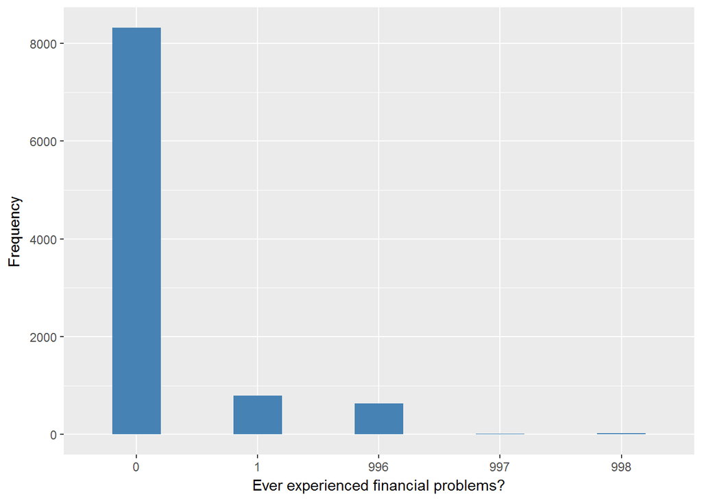

##### 2.1.3.3.1 Validation

### 2.1.4 Wave 4

#### 2.1.4.1 Study-specific variable description

The study-specific variable elected to be harmonised is:

- Name: `iafcon`
- Label: `Which of the phrases on the card best describes how you (and your spouse) are getting along financially these days?`
- Categories:
  - `1 = manage very well`
  - `2 = manage quite well`
  - `3 = get by alright`
  - `4 = don t manage very well`
  - `5 = have some financial difficulties`
  - `6 = have severe financial difficulties`
- Missings:
  - `-9 = Refusal`
  - `-8 = Don't Know`
  - `-2 = Schedule not applicable`
  - `-1 = Not applicable`
- Name: `fin_prob` from the previous wave
- Description:

IAFCON

| Sample size | Missing values |
| --- | --- |
| 11050 | 853 |

Category

|  | 1 | 2 | 3 | 4 | 5 | 6 |
| --- | --- | --- | --- | --- | --- | --- |
| Frequency | 3502.00 | 3348.0 | 2761.00 | 203.00 | 304.00 | 79.00 |
| Percentage | 31.69 | 30.3 | 24.99 | 1.84 | 2.75 | 0.71 |

Type of missing

|  | -9 | -8 | -2 | -1 | NA |
| --- | --- | --- | --- | --- | --- |
| Frequency | 13.00 | 8.00 | 0 | 832.00 | 0 |
| Percentage | 0.12 | 0.07 | 0 | 7.53 | 0 |

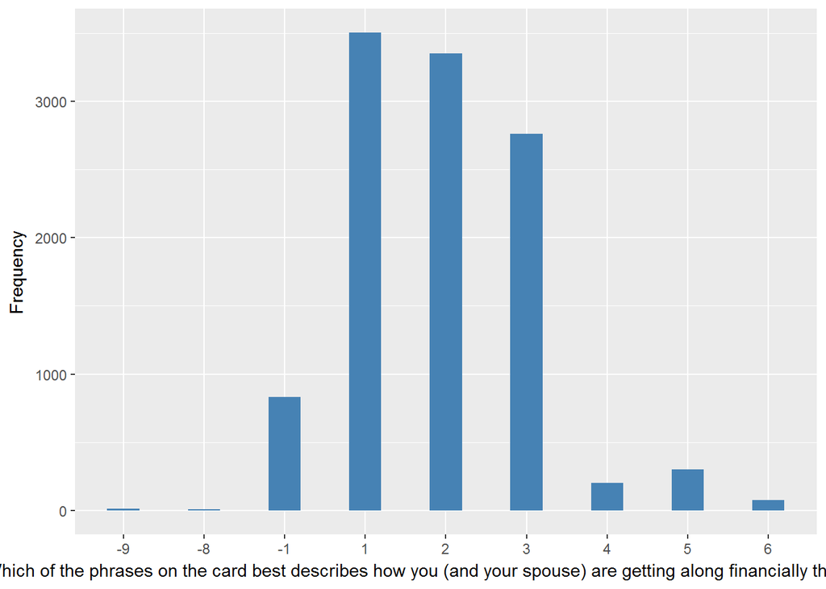

#### 2.1.4.2 Harmonisation algorithm

To recode the harmonize variable from the study-specific variable it has to be recoded as follows:

- `if fin_prob=1 or iafcon in 4,5,6 - into 1`
- `1,2,3 into 0`
- `-9 into 997`
- `-8 into 998`
- `-1 or -2 into 996`
- `NA into 999`

**R script:**

```r
same_indiv <- function(old, new) {

    new_2 <- matrix(NA, nrow = dim(new)[1], ncol = dim(old)[2])
    colnames(new_2) <- colnames(old)
    oldm <- as.matrix(old)

    for (i in 1:length(new$id)) {
        if (sum(new$id[i] == old$id) >= 1) {
            new_2[i, ] <- oldm[which(new$id[i] == old$id), ]
        } else {
            new_2[i, ] <- c(new$id[i], rep_len(NA, dim(old)[2] - 1))
        }
    }
    new_2 <- data.frame(new_2)
    new_22 <- data.frame(id = new_2$id, iafcon = new$iafcon, fin_prob = new_2$fin_prob)
    # id = new_2$id colname_form_OLD_table = new_2$colname_form_OLD_table
    # colname_form_NEW_table = new$colname_form_NEW_table
    new_22
}

# old = ELSA_ds_w3 (fin_prob) new = ELSA_w4_fin_prob (iafcon)

ELSA_w4_fin_prob_2 <- same_indiv(ELSA_ds_w3, ELSA_w4_fin_prob)

ELSA_ds_w4 <- tibble(id = ELSA_w4_fin_prob_2$id)

ELSA_w4_fin_prob_2$fin_prob <- car::recode(as.vector(ELSA_w4_fin_prob_2$fin_prob),
    "NA='-999'")
ELSA_w4_fin_prob_2$iafcon <- car::recode(as.vector(ELSA_w4_fin_prob_2$iafcon),
    "NA='-999'")

ELSA_ds_w4$fin_prob <- c(NA)
for (i in 1:dim(ELSA_w4_fin_prob_2[1])) {
    if (ELSA_w4_fin_prob_2$fin_prob[i] == 1 | ELSA_w4_fin_prob_2$iafcon[i] %in%
        c(4, 5, 6)) {
        ELSA_ds_w4$fin_prob[i] = 1
    } else if (ELSA_w4_fin_prob_2$iafcon[i] %in% c(1, 2, 3)) {
        ELSA_ds_w4$fin_prob[i] = 0
    } else if (ELSA_w4_fin_prob_2$iafcon[i] == -9) {
        ELSA_ds_w4$fin_prob[i] = 997
    } else if (ELSA_w4_fin_prob_2$iafcon[i] == -8) {
        ELSA_ds_w4$fin_prob[i] = 998
    } else if (ELSA_w4_fin_prob_2$iafcon[i] %in% c(-1, -2)) {
        ELSA_ds_w4$fin_prob[i] = 996
    }
}

ELSA_ds_w4$fin_prob <- car::recode(as.vector(ELSA_ds_w4$fin_prob), "NA='999'")
ELSA_ds_w4$fin_prob <- labelled(ELSA_ds_w4$fin_prob, labels = c(No = 0, Yes = 1,
    Missing = 999, `Do not know` = 998, Refuse = 997, `Not applicable` = 996,
    `Don't answer` = 995, `Not attempt/not done/not yet recorded` = 994, `Disable to measure` = 993,
    Impute = 992, `CAPI/interviewer error` = 991))
```

#### 2.1.4.3 Statistical description of the new harmonised variable

| Sample size | Missing values |
| --- | --- |
| 11050 | 816 |

Category

|  | 0 | 1 |
| --- | --- | --- |
| Frequency | 9188.00 | 1046.00 |
| Percentage | 83.15 | 9.47 |

Type of missing

|  | 991 | 992 | 993 | 994 | 995 | 996 | 997 | 998 | 999 | NA |
| --- | --- | --- | --- | --- | --- | --- | --- | --- | --- | --- |
| Frequency | 0 | 0 | 0 | 0 | 0 | 798.00 | 12.00 | 6.00 | 0 | 0 |
| Percentage | 0 | 0 | 0 | 0 | 0 | 7.22 | 0.11 | 0.05 | 0 | 0 |

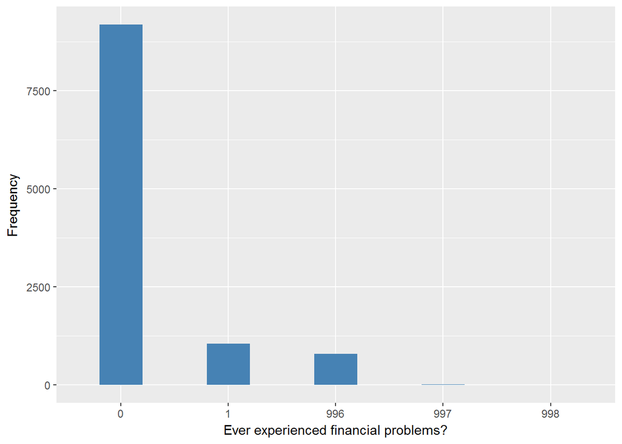

##### 2.1.4.3.1 Validation

### 2.1.5 Wave 5

#### 2.1.5.1 Study-specific variable description

The study-specific variable elected to be harmonised is:

- Name: `iafcon`
- Label: `Which of the phrases on the card best describes how you (and your spouse) are getting along financially these days?`
- Categories:
  - `1 = manage very well`
  - `2 = manage quite well`
  - `3 = get by alright`
  - `4 = don t manage very well`
  - `5 = have some financial difficulties`
  - `6 = have severe financial difficulties`
- Missings:
  - `-9 = Refusal`
  - `-8 = Don't Know`
  - `-2 = Schedule not applicable`
  - `-1 = Not applicable`
- Name: `fin_prob` from the previous wave
- Description:

IAFCON

| Sample size | Missing values |
| --- | --- |
| 10274 | 736 |

Category

|  | 1 | 2 | 3 | 4 | 5 | 6 |
| --- | --- | --- | --- | --- | --- | --- |
| Frequency | 3570.00 | 3116.00 | 2443.00 | 111.00 | 228.00 | 70.00 |
| Percentage | 34.75 | 30.33 | 23.78 | 1.08 | 2.22 | 0.68 |

Type of missing

|  | -9 | -8 | -2 | -1 | NA |
| --- | --- | --- | --- | --- | --- |
| Frequency | 12.00 | 14.00 | 0 | 710.00 | 0 |
| Percentage | 0.12 | 0.14 | 0 | 6.91 | 0 |

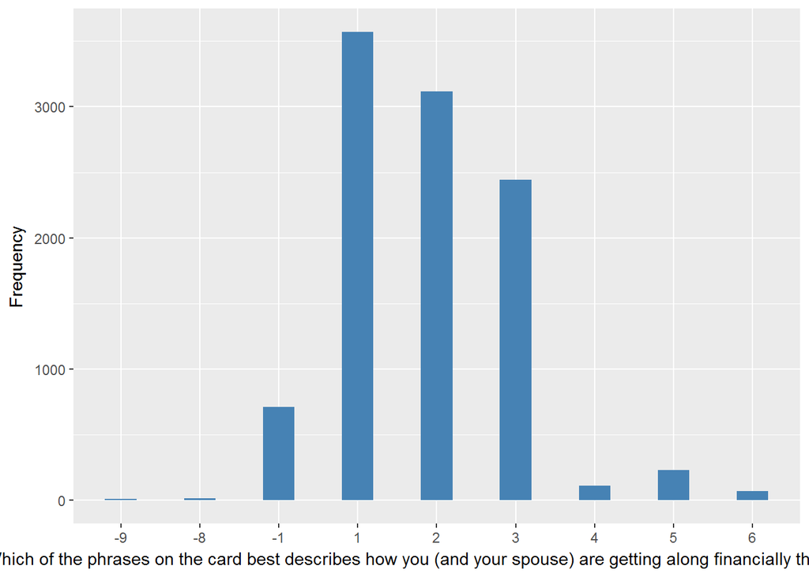

#### 2.1.5.2 Harmonisation algorithm

To recode the harmonize variable from the study-specific variable it has to be recoded as follows:

- `if fin_prob=1 or iafcon in 4,5,6 - into 1`
- `1,2,3 into 0`
- `-9 into 997`
- `-8 into 998`
- `-1 or -2 into 996`
- `NA into 999`

**R script:**

```r
same_indiv <- function(old, new) {

    new_2 <- matrix(NA, nrow = dim(new)[1], ncol = dim(old)[2])
    colnames(new_2) <- colnames(old)
    oldm <- as.matrix(old)

    for (i in 1:length(new$id)) {
        if (sum(new$id[i] == old$id) >= 1) {
            new_2[i, ] <- oldm[which(new$id[i] == old$id), ]
        } else {
            new_2[i, ] <- c(new$id[i], rep_len(NA, dim(old)[2] - 1))
        }
    }
    new_2 <- data.frame(new_2)
    new_22 <- data.frame(id = new_2$id, iafcon = new$iafcon, fin_prob = new_2$fin_prob)
    # id = new_2$id colname_form_OLD_table = new_2$colname_form_OLD_table
    # colname_form_NEW_table = new$colname_form_NEW_table
    new_22
}

# old = ELSA_ds_w4 (fin_prob) new = ELSA_w5_fin_prob (iafcon)

ELSA_w5_fin_prob_2 <- same_indiv(ELSA_ds_w4, ELSA_w5_fin_prob)

ELSA_ds_w5 <- tibble(id = ELSA_w5_fin_prob_2$id)

ELSA_w5_fin_prob_2$fin_prob <- car::recode(as.vector(ELSA_w5_fin_prob_2$fin_prob),
    "NA='-999'")
ELSA_w5_fin_prob_2$iafcon <- car::recode(as.vector(ELSA_w5_fin_prob_2$iafcon),
    "NA='-999'")

ELSA_ds_w5$fin_prob <- c(NA)
for (i in 1:dim(ELSA_w5_fin_prob_2[1])) {
    if (ELSA_w5_fin_prob_2$fin_prob[i] == 1 | ELSA_w5_fin_prob_2$iafcon[i] %in%
        c(4, 5, 6)) {
        ELSA_ds_w5$fin_prob[i] = 1
    } else if (ELSA_w5_fin_prob_2$iafcon[i] %in% c(1, 2, 3)) {
        ELSA_ds_w5$fin_prob[i] = 0
    } else if (ELSA_w5_fin_prob_2$iafcon[i] == -9) {
        ELSA_ds_w5$fin_prob[i] = 997
    } else if (ELSA_w5_fin_prob_2$iafcon[i] == -8) {
        ELSA_ds_w5$fin_prob[i] = 998
    } else if (ELSA_w5_fin_prob_2$iafcon[i] %in% c(-1, -2)) {
        ELSA_ds_w5$fin_prob[i] = 996
    }
}

ELSA_ds_w5$fin_prob <- car::recode(as.vector(ELSA_ds_w5$fin_prob), "NA='999'")
ELSA_ds_w5$fin_prob <- labelled(ELSA_ds_w5$fin_prob, labels = c(No = 0, Yes = 1,
    Missing = 999, `Do not know` = 998, Refuse = 997, `Not applicable` = 996,
    `Don't answer` = 995, `Not attempt/not done/not yet recorded` = 994, `Disable to measure` = 993,
    Impute = 992, `CAPI/interviewer error` = 991))
```

#### 2.1.5.3 Statistical description of the new harmonised variable

| Sample size | Missing values |
| --- | --- |
| 10274 | 700 |

Category

|  | 0 | 1 |
| --- | --- | --- |
| Frequency | 8487.00 | 1087.00 |
| Percentage | 82.61 | 10.58 |

Type of missing

|  | 991 | 992 | 993 | 994 | 995 | 996 | 997 | 998 | 999 | NA |
| --- | --- | --- | --- | --- | --- | --- | --- | --- | --- | --- |
| Frequency | 0 | 0 | 0 | 0 | 0 | 676.00 | 10.0 | 14.00 | 0 | 0 |
| Percentage | 0 | 0 | 0 | 0 | 0 | 6.58 | 0.1 | 0.14 | 0 | 0 |

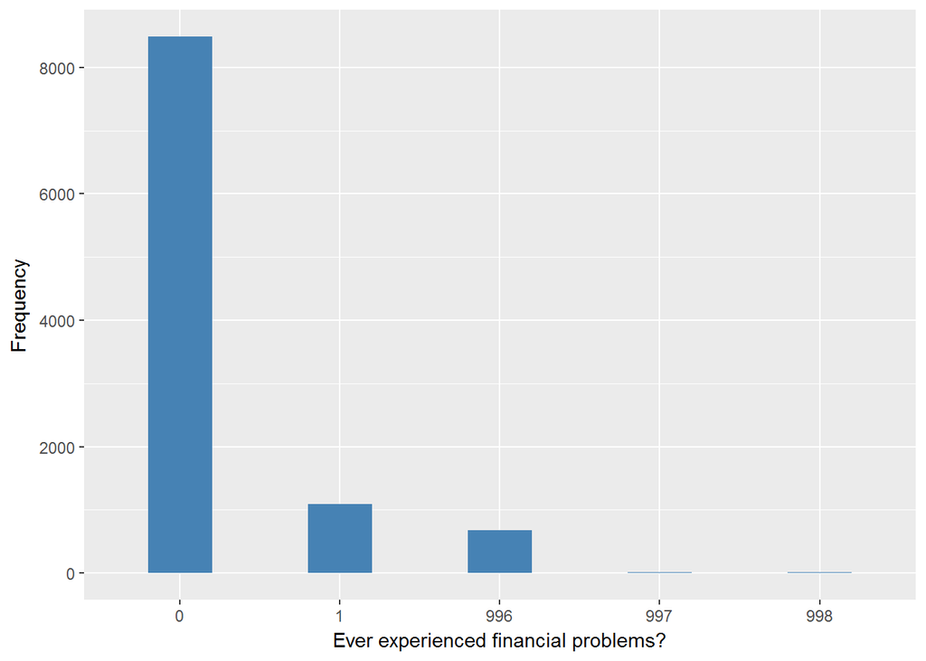

##### 2.1.5.3.1 Validation

### 2.1.6 Wave 6

#### 2.1.6.1 Study-specific variable description

The study-specific variable elected to be harmonised is:

- Name: `Iafcon`
- Label: `Which of the phrases on the card best describes how you (and your spouse) are getting along financially these days?`
- Categories:
  - `1 = manage very well`
  - `2 = manage quite well`
  - `3 = get by alright`
  - `4 = don t manage very well`
  - `5 = have some financial difficulties`
  - `6 = have severe financial difficulties`
- Missings:
  - `-9 = Refusal`
  - `-8 = Don't Know`
  - `-2 = Schedule not applicable`
  - `-1 = Not applicable`
- Name: `fin_prob` from the previous wave
- Description:

IAFCON

| Sample size | Missing values |
| --- | --- |
| 10601 | 746 |

Category

|  | 1 | 2 | 3 | 4 | 5 | 6 |
| --- | --- | --- | --- | --- | --- | --- |
| Frequency | 3595.00 | 3284.00 | 2462.00 | 175.00 | 262.00 | 77.00 |
| Percentage | 33.91 | 30.98 | 23.22 | 1.65 | 2.47 | 0.73 |

Type of missing

|  | -9 | -8 | -2 | -1 | NA |
| --- | --- | --- | --- | --- | --- |
| Frequency | 6.00 | 9.00 | 0 | 731.0 | 0 |
| Percentage | 0.06 | 0.08 | 0 | 6.9 | 0 |

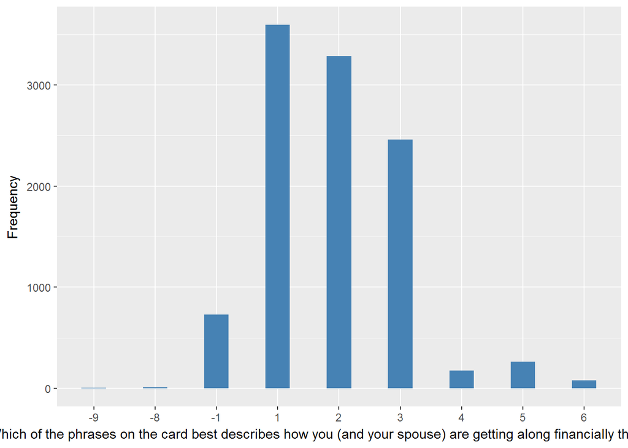

#### 2.1.6.2 Harmonisation algorithm

To recode the harmonize variable from the study-specific variable it has to be recoded as follows:

- `if fin_prob=1 or Iafcon in 4,5,6 - into 1`
- `1,2,3 into 0`
- `-9 into 997`
- `-8 into 998`
- `-1 or -2 into 996`
- `NA into 999`

**R script:**

```r
same_indiv <- function(old, new) {

    new_2 <- matrix(NA, nrow = dim(new)[1], ncol = dim(old)[2])
    colnames(new_2) <- colnames(old)
    oldm <- as.matrix(old)

    for (i in 1:length(new$id)) {
        if (sum(new$id[i] == old$id) >= 1) {
            new_2[i, ] <- oldm[which(new$id[i] == old$id), ]
        } else {
            new_2[i, ] <- c(new$id[i], rep_len(NA, dim(old)[2] - 1))
        }
    }
    new_2 <- data.frame(new_2)
    new_22 <- data.frame(id = new_2$id, Iafcon = new$Iafcon, fin_prob = new_2$fin_prob)
    # id = new_2$id colname_form_OLD_table = new_2$colname_form_OLD_table
    # colname_form_NEW_table = new$colname_form_NEW_table
    new_22
}

# old = ELSA_ds_w5 (fin_prob) new = ELSA_w6_fin_prob (Iafcon)

ELSA_w6_fin_prob_2 <- same_indiv(ELSA_ds_w5, ELSA_w6_fin_prob)

ELSA_ds_w6 <- tibble(id = ELSA_w6_fin_prob_2$id)

ELSA_w6_fin_prob_2$fin_prob <- car::recode(as.vector(ELSA_w6_fin_prob_2$fin_prob),
    "NA='-999'")
ELSA_w6_fin_prob_2$Iafcon <- car::recode(as.vector(ELSA_w6_fin_prob_2$Iafcon),
    "NA='-999'")

ELSA_ds_w6$fin_prob <- c(NA)
for (i in 1:dim(ELSA_w6_fin_prob_2[1])) {
    if (ELSA_w6_fin_prob_2$fin_prob[i] == 1 | ELSA_w6_fin_prob_2$Iafcon[i] %in%
        c(4, 5, 6)) {
        ELSA_ds_w6$fin_prob[i] = 1
    } else if (ELSA_w6_fin_prob_2$Iafcon[i] %in% c(1, 2, 3)) {
        ELSA_ds_w6$fin_prob[i] = 0
    } else if (ELSA_w6_fin_prob_2$Iafcon[i] == -9) {
        ELSA_ds_w6$fin_prob[i] = 997
    } else if (ELSA_w6_fin_prob_2$Iafcon[i] == -8) {
        ELSA_ds_w6$fin_prob[i] = 998
    } else if (ELSA_w6_fin_prob_2$Iafcon[i] %in% c(-1, -2)) {
        ELSA_ds_w6$fin_prob[i] = 996
    }
}

ELSA_ds_w6$fin_prob <- car::recode(as.vector(ELSA_ds_w6$fin_prob), "NA='999'")
ELSA_ds_w6$fin_prob <- labelled(ELSA_ds_w6$fin_prob, labels = c(No = 0, Yes = 1,
    Missing = 999, `Do not know` = 998, Refuse = 997, `Not applicable` = 996,
    `Don't answer` = 995, `Not attempt/not done/not yet recorded` = 994, `Disable to measure` = 993,
    Impute = 992, `CAPI/interviewer error` = 991))
```

#### 2.1.6.3 Statistical description of the new harmonised variable

| Sample size | Missing values |
| --- | --- |
| 10601 | 696 |

Category

|  | 0 | 1 |
| --- | --- | --- |
| Frequency | 8665.00 | 1240.0 |
| Percentage | 81.74 | 11.7 |

Type of missing

|  | 991 | 992 | 993 | 994 | 995 | 996 | 997 | 998 | 999 | NA |
| --- | --- | --- | --- | --- | --- | --- | --- | --- | --- | --- |
| Frequency | 0 | 0 | 0 | 0 | 0 | 683.00 | 6.00 | 7.00 | 0 | 0 |
| Percentage | 0 | 0 | 0 | 0 | 0 | 6.44 | 0.06 | 0.07 | 0 | 0 |

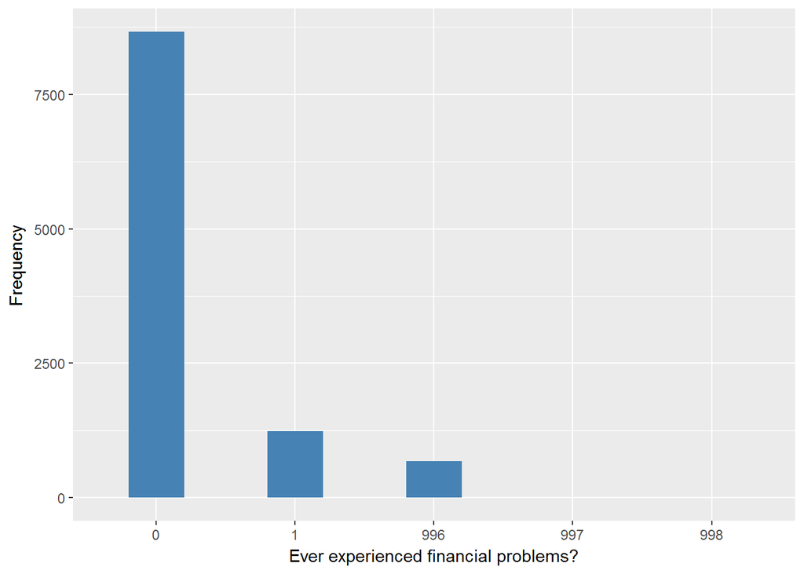

#### 2.1.6.4 Validation

### 2.1.7 Wave 7

#### 2.1.7.1 Study-specific variable description

The study-specific variable elected to be harmonised is:

- Name: `Iafcon`
- Label: `Which of the phrases on the card best describes how you (and your spouse) are getting along financially these days?`
- Categories:
  - `1 = manage very well`
  - `2 = manage quite well`
  - `3 = get by alright`
  - `4 = don t manage very well`
  - `5 = have some financial difficulties`
  - `6 = have severe financial difficulties`
- Missings:
  - `-9 = Refusal`
  - `-8 = Don't Know`
  - `-2 = Schedule not applicable`
  - `-1 = Not applicable`
- Name: `fin_prob` from the previous wave
- Description:

| Sample size | Missing values |
| --- | --- |
| 9666 | 643 |

Category

|  | 1 | 2 | 3 | 4 | 5 | 6 |
| --- | --- | --- | --- | --- | --- | --- |
| Frequency | 3859.00 | 2829.00 | 1970.00 | 127.00 | 182.00 | 56.00 |
| Percentage | 39.92 | 29.27 | 20.38 | 1.31 | 1.88 | 0.58 |

Type of missing

|  | -9 | -8 | -2 | -1 | NA |
| --- | --- | --- | --- | --- | --- |
| Frequency | 10.0 | 10.0 | 0 | 623.00 | 0 |
| Percentage | 0.1 | 0.1 | 0 | 6.45 | 0 |

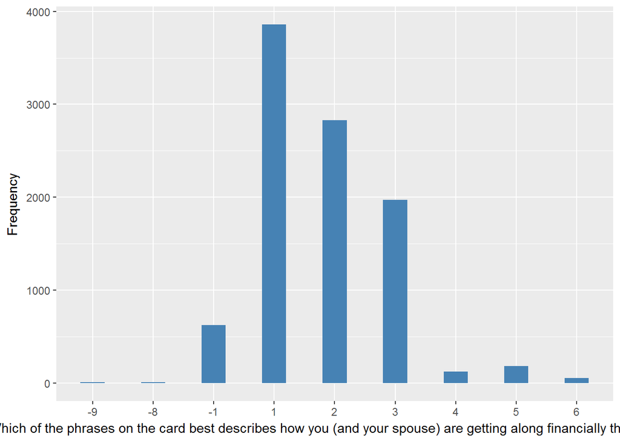

#### 2.1.7.2 Harmonisation algorithm

To recode the harmonize variable from the study-specific variable it has to be recoded as follows:

- `if fin_prob=1 or Iafcon in 4,5,6 - into 1`
- `1,2,3 into 0`
- `-9 into 997`
- `-8 into 998`
- `-1 or -2 into 996`
- `NA into 999`

**R script:**

```r
same_indiv <- function(old, new) {

    new_2 <- matrix(NA, nrow = dim(new)[1], ncol = dim(old)[2])
    colnames(new_2) <- colnames(old)
    oldm <- as.matrix(old)

    for (i in 1:length(new$id)) {
        if (sum(new$id[i] == old$id) >= 1) {
            new_2[i, ] <- oldm[which(new$id[i] == old$id), ]
        } else {
            new_2[i, ] <- c(new$id[i], rep_len(NA, dim(old)[2] - 1))
        }
    }
    new_2 <- data.frame(new_2)
    new_22 <- data.frame(id = new_2$id, Iafcon = new$Iafcon, fin_prob = new_2$fin_prob)
    # id = new_2$id colname_form_OLD_table = new_2$colname_form_OLD_table
    # colname_form_NEW_table = new$colname_form_NEW_table
    new_22
}

# old = ELSA_ds_w6 (fin_prob) new = ELSA_w7_fin_prob (Iafcon)

ELSA_w7_fin_prob_2 <- same_indiv(ELSA_ds_w6, ELSA_w7_fin_prob)

ELSA_ds_w7 <- tibble(id = ELSA_w7_fin_prob_2$id)

ELSA_w7_fin_prob_2$fin_prob <- car::recode(as.vector(ELSA_w7_fin_prob_2$fin_prob),
    "NA='-999'")
ELSA_w7_fin_prob_2$Iafcon <- car::recode(as.vector(ELSA_w7_fin_prob_2$Iafcon),
    "NA='-999'")

ELSA_ds_w7$fin_prob <- c(NA)
for (i in 1:dim(ELSA_w7_fin_prob_2[1])) {
    if (ELSA_w7_fin_prob_2$fin_prob[i] == 1 | ELSA_w7_fin_prob_2$Iafcon[i] %in%
        c(4, 5, 6)) {
        ELSA_ds_w7$fin_prob[i] = 1
    } else if (ELSA_w7_fin_prob_2$Iafcon[i] %in% c(1, 2, 3)) {
        ELSA_ds_w7$fin_prob[i] = 0
    } else if (ELSA_w7_fin_prob_2$Iafcon[i] == -9) {
        ELSA_ds_w7$fin_prob[i] = 997
    } else if (ELSA_w7_fin_prob_2$Iafcon[i] == -8) {
        ELSA_ds_w7$fin_prob[i] = 998
    } else if (ELSA_w7_fin_prob_2$Iafcon[i] %in% c(-1, -2)) {
        ELSA_ds_w7$fin_prob[i] = 996
    }
}

ELSA_ds_w7$fin_prob <- car::recode(as.vector(ELSA_ds_w7$fin_prob), "NA='999'")
ELSA_ds_w7$fin_prob <- labelled(ELSA_ds_w7$fin_prob, labels = c(No = 0, Yes = 1,
    Missing = 999, `Do not know` = 998, Refuse = 997, `Not applicable` = 996,
    `Don't answer` = 995, `Not attempt/not done/not yet recorded` = 994, `Disable to measure` = 993,
    Impute = 992, `CAPI/interviewer error` = 991))
```

#### 2.1.7.3 Statistical description of the new harmonised variable

| Sample size | Missing values |
| --- | --- |
| 9666 | 607 |

Category

|  | 0 | 1 |
| --- | --- | --- |
| Frequency | 7892.00 | 1167.00 |
| Percentage | 81.65 | 12.07 |

Type of missing

|  | 991 | 992 | 993 | 994 | 995 | 996 | 997 | 998 | 999 | NA |
| --- | --- | --- | --- | --- | --- | --- | --- | --- | --- | --- |
| Frequency | 0 | 0 | 0 | 0 | 0 | 587.00 | 10.0 | 10.0 | 0 | 0 |
| Percentage | 0 | 0 | 0 | 0 | 0 | 6.07 | 0.1 | 0.1 | 0 | 0 |

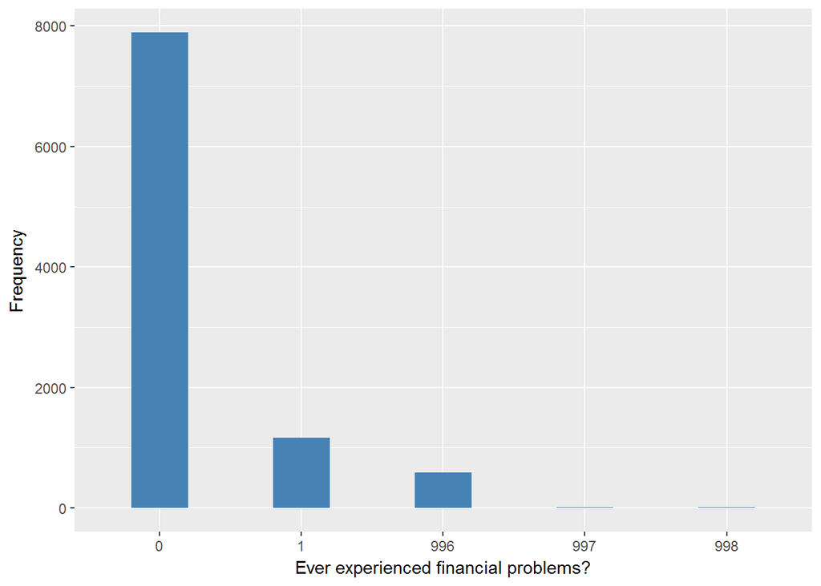

#### 2.1.7.4 Validation

# 3 Quality estimation